# Parlamentares no Twitter: Como pia o Congresso Nacional?

Matheus Alves dos Santos

04 de abril de 2019

Na maioria dos países democráticos, os parlamentares costumam adotar perfis em redes sociais como canais de comunicação não-oficiais, através dos quais podem não somente divulgar sua atuação política, mas também comentar assuntos cotidianos e entrar em contato direto da população em geral.

O Twitter tem atraído bastante a atenção dos brasileiros nos últimos meses e, muitas vezes, isso não se deve às suas funcionalidades, mas às polêmicas geradas a partir de postagens de figuras políticas do país. Nesse sentido, decidiu-se explorar os dados de nossos parlamentares *twitteiros* na tentativa de compreender melhor como *tweeta* o Congresso Nacional brasileiro.

## Preparação do Ambiente

Para as análises apresentadas a seguir, foram utilizadas as bibliotecas **tidyverse**, **ggplot2**, **ggbeeswarm** e **scales**. Já os dados utilizados estão estruturados da seguinte maneira:

```r
glimpse(atividade)
```

```
## Observations: 608
## Variables: 19
## $ id_parlamentar        <chr> "204554", "204521", "204379", "204560", ...
## $ casa                  <chr> "câmara", "câmara", "câmara", "câmara", ...
## $ nome_eleitoral        <chr> "ABÍLIO SANTANA", "ABOU ANNI", "ACÁCIO F...
## $ partido               <chr> "PR", "PSL", "PROS", "PSDB", "NOVO", "PP...
## $ UF                    <chr> "BA", "SP", "AP", "BA", "SP", "GO", "MG"...
## $ twitter               <chr> "AbilioSantana_", "abouannipv", "Favacho...
## $ seguidores            <dbl> NA, NA, NA, NA, 4652, NA, NA, NA, NA, NA...
## $ segue                 <dbl> NA, NA, NA, NA, 315, NA, NA, NA, NA, NA,...
## $ n_proprio             <dbl> 0, 0, 0, 0, 99, 0, 0, 0, 0, 0, 0, 0, NA,...
## $ n_retweet             <dbl> 0, 0, 0, 0, 9, 0, 0, 0, 0, 0, 0, 0, NA, ...
## $ engaj_total           <dbl> 0, 0, 0, 0, 7090, 0, 0, 0, 0, 0, 0, 0, N...
## $ engaj_total_proprio   <dbl> 0, 0, 0, 0, 6701, 0, 0, 0, 0, 0, 0, 0, N...
## $ engaj_total_retweet   <dbl> 0, 0, 0, 0, 389, 0, 0, 0, 0, 0, 0, 0, NA...
## $ engaj_mediano         <dbl> 0.0, 0.0, 0.0, 0.0, 26.5, 0.0, 0.0, 0.0,...
## $ engaj_mediano_proprio <dbl> 0.0, 0.0, 0.0, 0.0, 22.5, 0.0, 0.0, 0.0,...
## $ engaj_mediano_retweet <dbl> 0.0, 0.0, 0.0, 0.0, 0.0, 0.0, 0.0, 0.0, ...
## $ engaj_max             <dbl> 0, 0, 0, 0, 1031, 0, 0, 0, 0, 0, 0, 0, N...
## $ engaj_max_proprio     <dbl> 0, 0, 0, 0, 1031, 0, 0, 0, 0, 0, 0, 0, N...
## $ engaj_max_retweet     <dbl> 0, 0, 0, 0, 99, 0, 0, 0, 0, 0, 0, 0, NA,...
```

## Análises

### 1 — Quais partidos mais produzem conteúdo no Twitter?

Para contabilizar o conteúdo produzido no Twitter será utilizada a soma do número de tweets e retweets de cada parlamentar. Considerando que o número de parlamentares eleitos por partido varia muito, será utilizada a mediana da soma (com agrupamento por partido) citada anteriormente. Por fim, não serão analisados parlamentares sem partido.

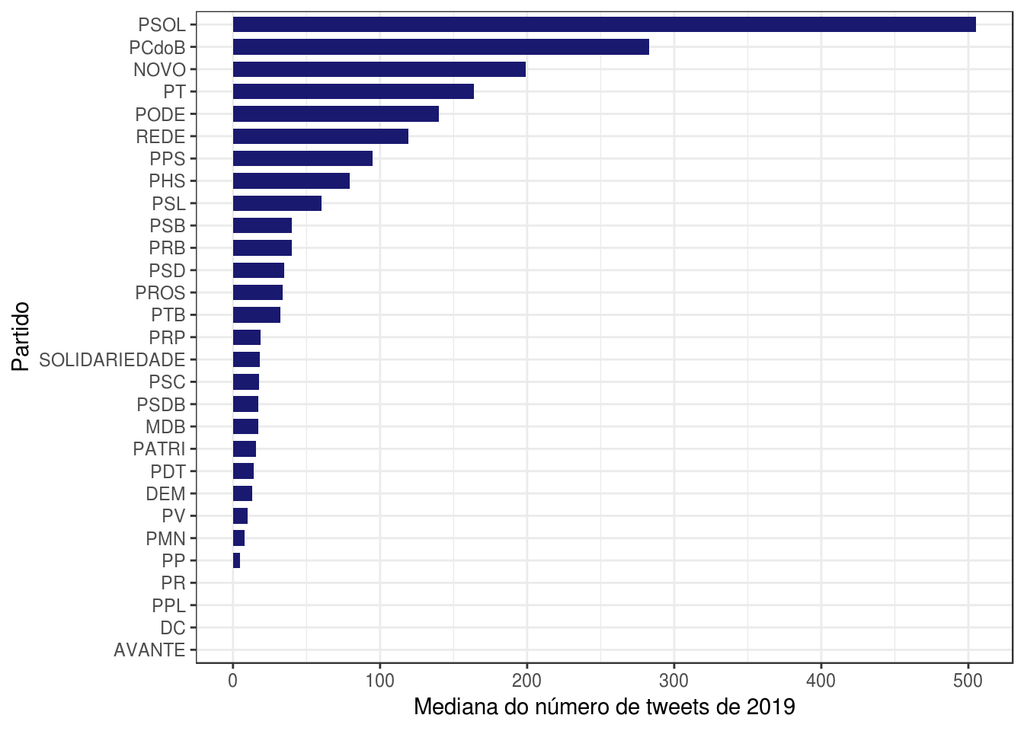

```r
parlamentares_com_tt <- atividade %>% filter(!is.na(twitter))

parlamentares_com_tt <- parlamentares_com_tt %>% mutate(total_tweets = n_proprio + n_retweet)

parlamentares_com_tt %>%
  group_by(partido) %>%
  filter(partido != "S/Partido") %>%
  summarise(mediana_tweets = median(total_tweets)) %>%
    ggplot(aes(x = reorder(partido, mediana_tweets), y = mediana_tweets)) +
    geom_bar(stat = 'identity', fill = 'midnightblue', width = 0.7) +
    labs(x = 'Partido', y = 'Mediana do número de tweets de 2019') +
    coord_flip()
```

### 2 — No partido com mais conteúdo produzido, quais parlamentares *tweetam* mais?

Dentre os partidos que mais produzem conteúdo no *Twitter*, os parlamentares do PSOL destacam-se pela quantidade que produzem, mesmo que sejam tão pouco numerosos em relação a outros partidos. No entanto, ainda é necessário compreender a contribuição de cada um desses políticos para este resultado.

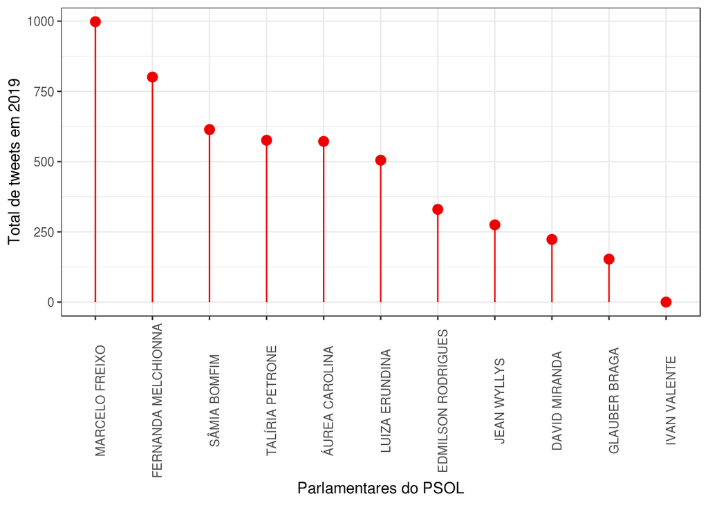

```r
parlamentares_com_tt %>%
  filter(partido == "PSOL") %>%
    ggplot(aes(x = reorder(nome_eleitoral, -total_tweets), y = total_tweets)) +
    geom_segment(aes(xend = nome_eleitoral, y = 0, yend = total_tweets), show.legend = FALSE, color = 'red2') +
    geom_point(size = 3, show.legend = FALSE, color = 'red2') +
    labs(x = "Parlamentares do PSOL", y = "Total de tweets em 2019") +
    theme(axis.text.x = element_text(angle = 90))
```

Os parlamentares do PSOL apresentam níveis bastante variados de produção de conteúdo, destacando-se **Marcelo Freixo** como maior *twitteiro* de seu partido e **Ivan Valente** que não deu um pio em 2019. É perceptível ainda que, no geral, as mulheres eleitas pelo PSOL são mais ativas no Twitter do que os homens, bem como que os parlamentares conhecidos nacionalmente não são necessariamente *twitteiros* natos.

### 3 — O espectro político impacta no engajamento gerado pelos partidos?

Para responder esta pergunta, é necessário entender onde cada partido político se localiza no espectro político. Dada a subjetividade desta avaliação, adotou-se o modo como os próprios partidos se descrevem e não a atuação de seus parlamentares, gerando três grandes grupos de partidos: esquerda, centro e direita. Considerando a diferença no número de partidos e de parlamentares em cada um desses grupos, decidiu-se utilizar o engajamento mediano como métrica da análise. Além disso, por questões de visualização, adotou-se uma escala logarítmica.

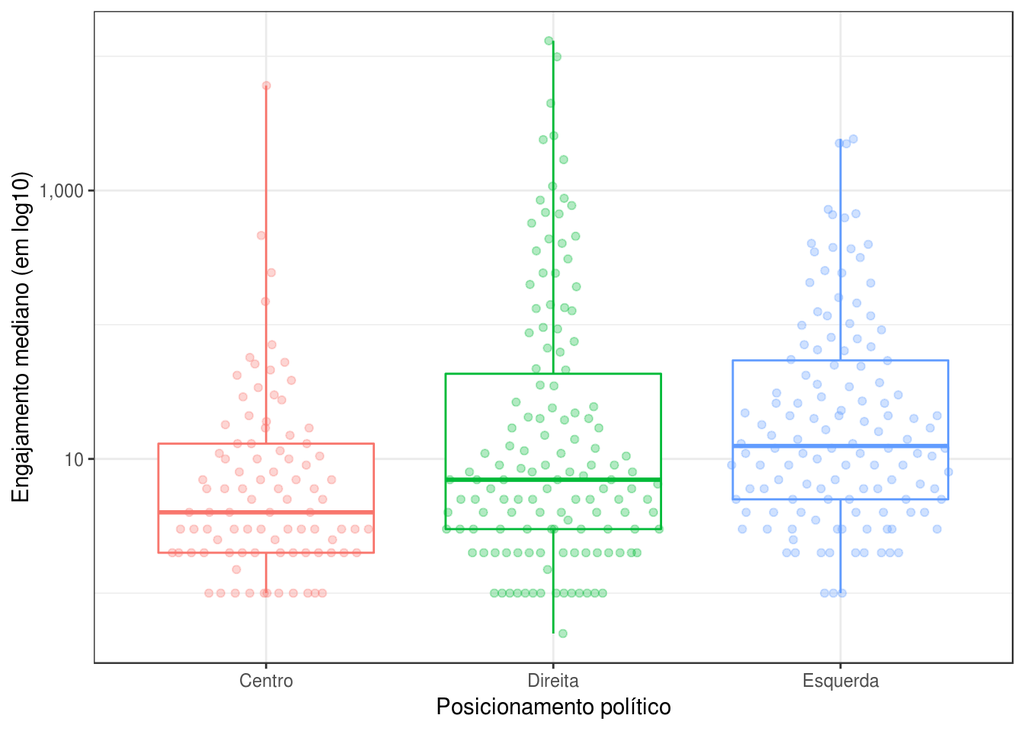

```r
centro <- c("AVANTE", "MDB", "PSD", "PSDB", "PTB", "SOLIDARIEDADE")
esquerda <- c("PCdoB", "PDT", "PMN", "PPL", "PPS", "PROS", "PSB", "PSOL", "PT", "PV", "REDE")
direita <- c("DC", "DEM", "NOVO", "PATRI", "PHS", "PODE", "PP", "PR", "PRB", "PRP",  "PSC", "PSL")

parlamentares_com_tt <- parlamentares_com_tt %>%
  mutate(posicionamento = ifelse(partido %in% centro, "Centro",
                            ifelse(partido %in% esquerda, "Esquerda",
                              ifelse(partido %in% direita, "Direita", NA))))

parlamentares_com_tt %>%
  filter(!is.na(posicionamento)) %>%
    ggplot(aes(x = posicionamento, y = engaj_mediano, color = posicionamento)) +
    geom_boxplot(coef = 1000, show.legend = FALSE) +
    geom_quasirandom(alpha = .3, show.legend = FALSE) +
    labs(x = "Posicionamento político", y = "Engajamento mediano (em log10)") +
    scale_y_log10(labels = comma)
```

Os três grandes grupos do espectro político apresentaram características bem peculiares. Excetuando-se alguns poucos parlamentares, os partidos centristas tem resultados bem inferiores aos demais quanto ao engajamento gerado via Twitter, o que não chega a surpreender dado o nosso cenário político. Já a esquerda conta com a maior das medianas encontradas e engajamentos mais homogêneos entre seus parlamentares. Por fim, a direita conta com valores mais dispersos, mas também com os parlamentares que geram os maiores engajamentos.

### 4 — E as UFs desses parlamentares, tem impacto no engajamento?

Assim como na análise anterior, adotou-se uma escala logarítmica. Também visando a melhor compreensão do leitor, os *boxplots* foram coloridos de acordo com a região do Brasil a que cada estado pertence.

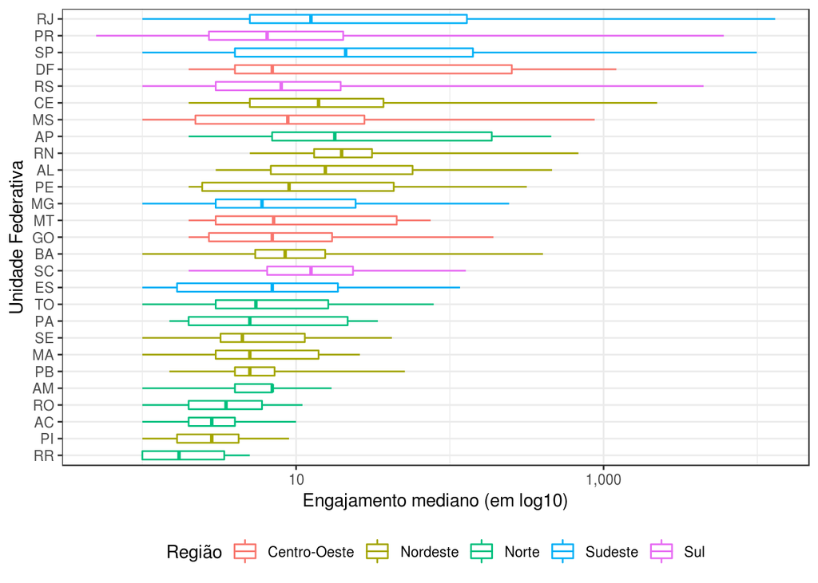

```r
centrooeste <- c("DF", "GO", "MS", "MT")
nordeste <- c("AL", "BA", "CE", "MA", "PB", "PE", "PI", "RN", "SE")
norte <- c("AC", "AP", "AM", "PA", "RO", "RR", "TO")
sudeste <- c("ES", "MG", "RJ", "SP")
sul <- c("PR", "RS", "SC")

parlamentares_com_tt <- parlamentares_com_tt %>%
  mutate(regiao = ifelse(UF %in% centrooeste, "Centro-Oeste",
                            ifelse(UF %in% nordeste, "Nordeste",
                              ifelse(UF %in% norte, "Norte",
                                ifelse(UF %in% sudeste, "Sudeste", "Sul")))))

parlamentares_com_tt %>%
  ggplot(aes(x = reorder(UF, engaj_mediano), y = engaj_mediano, color = regiao)) +
  labs(x = "Unidade Federativa", y = "Engajamento mediano (em log10)") +
  guides(color = guide_legend(title = "Região")) +
  geom_boxplot(width = .5, coef = 1000) +
  theme(legend.position="bottom") +
  scale_y_log10(labels = comma) +
  coord_flip()
```

Os estados do sul e sudeste brasileiros são aqueles em que residem os parlamentares com maior engajamento no Twitter, em especial **Rio de Janeiro**, **Paraná** e **São Paulo**. Já os parlamentares dos estados do norte e nordeste são aqueles que tem as menores máximas do engajamento mediano nessa rede social. No entanto, o engajamento gerado por parlamentares desses estados é bem mais homogêneo, de modo que são identificadas situações curiosas como o **Rio Grande do Norte** alcançando uma mediana muito semelhante à de **São Paulo**.

Sem causar qualquer surpresa, as chances de encontrar um político paulista *hitando* no Twitter é bem maior do que um encontrar um político paraibano fazendo tanto sucesso.